# titulo

## Hipótesis

¿Existe una relación entre la puntuación de un vino y su precio? Se podría explorar si los vinos con puntuaciones más altas tienden a tener precios más elevados, o si hay alguna tendencia particular en la relación entre estas dos variables.

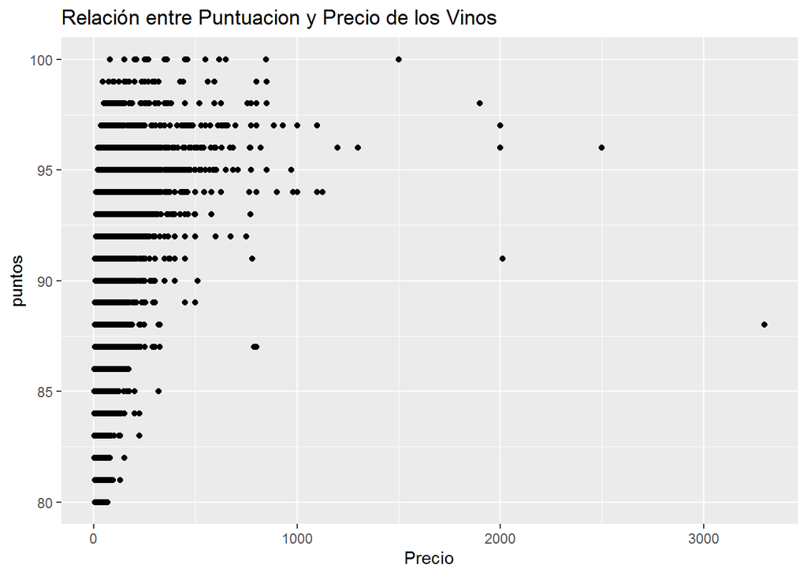

```r
ggplot(data = vinos, aes(x = precio, y = puntos)) +
  geom_point() +
  labs(x = "Precio", y = "puntos") +
  ggtitle("Relación entre Puntuacion y Precio de los Vinos")
```

```r
## Correccion feedback TP2, me olvide de analizar y sacar una conclusion en el TP2. Aqui va el analisis y la conclusión.
```

*Esto sugiere que otros factores, como la variedad de uva, la región de origen o las prácticas de producción, podrían estar influyendo en la puntuación de los vinos además del precio. Es importante considerar que el precio de un vino puede estar determinado por múltiples factores, como la calidad de las uvas, el método de producción, la reputación de la bodega, entre otros.*

*En conclusión, según el gráfico de dispersión, no se observa una relación lineal directa entre la puntuación y el precio de los vinos en el conjunto de datos analizado.*

¿Cuáles son los países con la mayor cantidad de vinos en el conjunto de datos? Se podría analizar la distribución de los vinos según el país de origen y determinar cuáles son los países más representados en el conjunto.

```r
# Calcular la cantidad de vinos por país y almacenar los resultados en un objeto llamado "conteo_paises"

conteo_paises <- table(vinos$pais)
conteo_paises
```

```
##
##             Alemania            Argentina              Armenia
##                 2165                 3800                    2
##            Australia              Austria Bosnia y Herzegovina
##                 2329                 3345                    2
##               Brazil             Bulgaria               Canadá
##                   52                  141                  257
##                Chile                China               Chipre
##                 4472                    1                   11
##              Croacia               Egipto           Eslovaquia
##                   73                    1                    1
##            Eslovenia               España       Estados Unidos
##                   87                 6645                54504
##              Francia              Georgia               Grecia
##                22093                   86                  466
##              Hungría                India           Inglaterra
##                  146                    9                   74
##               Israel               Italia               Líbano
##                  505                19540                   35
##           Luxemburgo            Macedonia            Marruecos
##                    6                   12                   28
##               México             Moldavia        Nueva Zelanda
##                   70                   59                 1419
##                 Perú             Portugal      República Checa
##                   16                 5691                   12
##              Rumania               Serbia            Sudáfrica
##                  120                   12                 1401
##                Suiza              Turquía              Ucrania
##                    7                   90                   14
##              Uruguay
##                  109
```

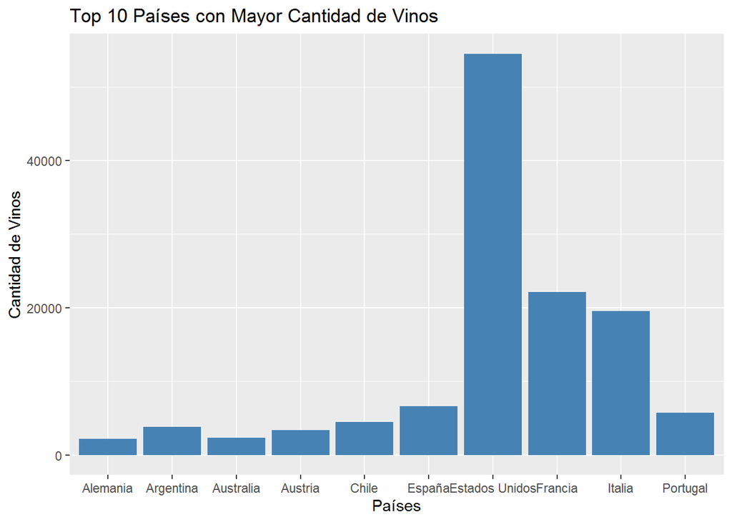

```r
# Crear un dataframe con los datos de conteo de países
datos_paises <- data.frame(pais = names(conteo_paises), cantidad = as.numeric(conteo_paises))
top_paises <- head(names(sort(conteo_paises, decreasing = TRUE)), 10)
vinos_top <- vinos[vinos$pais %in% top_paises, ]

## se corrigio, conforme al feedback del TP2..."No hace falta que armes un data.frame así. Acá podés simplemente pasarle vinos_top."
ggplot(data = vinos_top, aes(x = pais)) +
  geom_bar(fill = "steelblue") +
  labs(x = "Países", y = "Cantidad de Vinos") +
  ggtitle("Top 10 Países con Mayor Cantidad de Vinos")
```

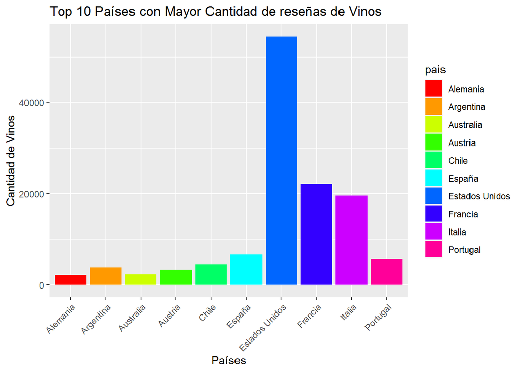

```r
## Elio Conforme a tu feedback TP2:
## "Esto se podría hacer más fácil con un group_by(pais) y summarise(n = n()). Para seleccionar el top 10, podés usar arrange y head o directamente slice_max()"
## Procedi a calcular de la siguiente manera.

datos_paises <- vinos %>%
  group_by(pais) %>%
  summarise(n = n())

top_paises <- datos_paises %>%
  arrange(desc(n)) %>%
  slice_max(n = 10, order_by = n)

vinos_top <- vinos %>%
  filter(pais %in% top_paises$pais)


top_paises <- datos_paises %>%
  arrange(desc(n)) %>%
  slice_max(n = 10, order_by = n)

ggplot(top_paises, aes(x = pais, y = n, fill = pais)) +
  geom_bar(stat = "identity") +
  labs(x = "Países", y = "Cantidad de Vinos", title = "Top 10 Países con Mayor Cantidad de reseñas de Vinos") +
  theme(axis.text.x = element_text(angle = 45, hjust = 1)) +
  scale_fill_manual(values = rainbow(length(top_paises$pais)))
```

¿Cuál es la variedad de uva más común en los vinos del conjunto de datos? Se podría investigar la frecuencia de las diferentes variedades de uva presentes en los vinos y determinar cuál es la más prevalente.

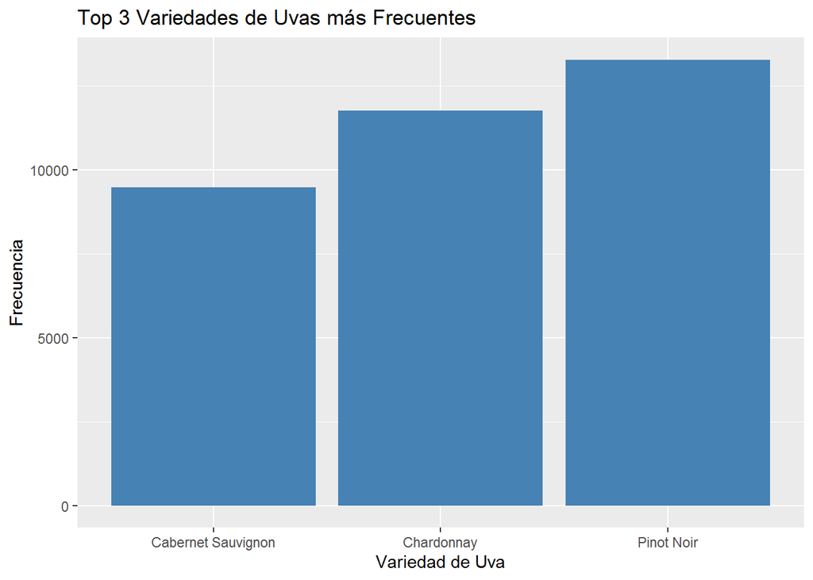

```r
# Calcular la frecuencia de las variedades de uva
frecuencia_variedades <- table(vinos$variedad)

# Convertir la tabla de frecuencias en un dataframe
  df_variedades <- data.frame(variedad = names(frecuencia_variedades),
                           frecuencia = as.numeric(frecuencia_variedades))

# Ordenar las variedades de uva por frecuencia descendente
  df_variedades <- df_variedades[order(df_variedades$frecuencia, decreasing = TRUE), ]

# Graficar las frecuencias de las variedades de uva
  #ggplot(data = df_variedades, aes(x = reorder(variedad, -frecuencia), y = frecuencia)) +
  #geom_bar(stat = "identity", fill = "steelblue") +
  #labs(x = "Variedad de Uva", y = "Frecuencia") +
  #ggtitle("Variedades de Uva más Comunes en los Vinos")


  # Seleccionar las 3 variedades de uva con mayor frecuencia
  top_3_variedades <- df_variedades[1:3,]

# Ordenar las variedades de uva por frecuencia ascendente
top_3_variedades <- top_3_variedades[order(top_3_variedades$frecuencia), ]

# Reordenar las variedades de uva en el gráfico
df_variedades$variedad <- factor(df_variedades$variedad, levels = top_3_variedades$variedad)

# Graficar las frecuencias de las 3 variedades de uva más frecuentes
  ggplot(data = na.omit(df_variedades), aes(x = variedad, y = frecuencia)) +
  geom_bar(stat = "identity", fill = "steelblue") +
  labs(x = "Variedad de Uva", y = "Frecuencia") +
  ggtitle("Top 3 Variedades de Uvas más Frecuentes")
```

*Nota: Observamos el Top 3 de las variedades de uva mas frecuentes en todo el mundo.*

1. *Pinot Noir:13.272*
2. *Chardonnay: 11.753*
3. *CabernetbSauvignon: 9.472*

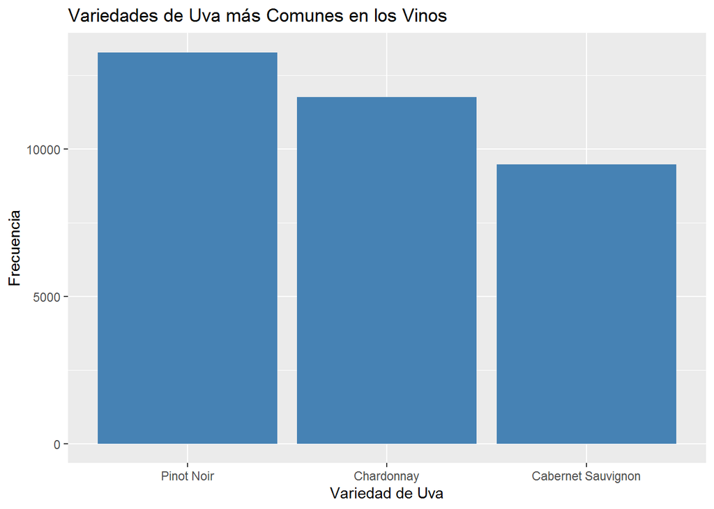

```r
## De acuerdo a corrección hecha en feedback TP2 , procedi a simplificar el codigo usando la funcion dplyr.
df_variedades <- vinos %>%
  count(variedad) %>%
  arrange(desc(n)) %>%
  mutate(variedad = factor(variedad, levels = head(variedad, 3))) %>%
  rename(frecuencia = n)

ggplot(data = na.omit(df_variedades), aes(x = variedad, y = frecuencia)) +
  geom_bar(stat = "identity", fill = "steelblue") +
  labs(x = "Variedad de Uva", y = "Frecuencia") +
  ggtitle("Variedades de Uva más Comunes en los Vinos")
```